# Biased Regression Methods for Prediction

Instability of OLS, Ridge, Lasso, PLS, MCP, SCAD; Grouped & Fused Lasso

Author

Alexander McLain

Published

August 31, 2026

**Datasets used in this lab**

> • **Diabetes progression** (Efron et al.) via `lars::diabetes`: outcome is a quantitative measure of disease progression one year after baseline; predictors are clinical/lab measures.

> • **Air quality (Ozone)** via `airquality`: daily ozone levels in New York—used here to illustrate **fused lasso** as a denoising tool for an environmental time series.

# 1 Data and Train/Test Split (Diabetes)

```r
data(diabetes, package = "lars")

# X: 10 predictors (matrix), y: outcome (numeric)
X <- diabetes$x
y <- diabetes$y

# Make a tibble with one column per predictor (no list-columns)
df <- tibble::as_tibble(X) %>%
  mutate(y = as.numeric(y))

## This data is formatted strangely. I had to export and import to fix.
write.csv(df, "diabetes.csv")
df <- read_csv("diabetes.csv")[,-1]
names(df) <- c("age","sex","bmi","map","tc","ldl","hdl","tch","ltg","glu", "y")

# correlation of predictors
cor(df %>% dplyr::select(!starts_with("y"))) %>%
  round(2) %>%
  kable()
```

|  | age | sex | bmi | map | tc | ldl | hdl | tch | ltg | glu |
| --- | --- | --- | --- | --- | --- | --- | --- | --- | --- | --- |
| age | 1.00 | 0.17 | 0.19 | 0.34 | 0.26 | 0.22 | -0.08 | 0.20 | 0.27 | 0.30 |
| sex | 0.17 | 1.00 | 0.09 | 0.24 | 0.04 | 0.14 | -0.38 | 0.33 | 0.15 | 0.21 |
| bmi | 0.19 | 0.09 | 1.00 | 0.40 | 0.25 | 0.26 | -0.37 | 0.41 | 0.45 | 0.39 |
| map | 0.34 | 0.24 | 0.40 | 1.00 | 0.24 | 0.19 | -0.18 | 0.26 | 0.39 | 0.39 |
| tc | 0.26 | 0.04 | 0.25 | 0.24 | 1.00 | 0.90 | 0.05 | 0.54 | 0.52 | 0.33 |
| ldl | 0.22 | 0.14 | 0.26 | 0.19 | 0.90 | 1.00 | -0.20 | 0.66 | 0.32 | 0.29 |
| hdl | -0.08 | -0.38 | -0.37 | -0.18 | 0.05 | -0.20 | 1.00 | -0.74 | -0.40 | -0.27 |
| tch | 0.20 | 0.33 | 0.41 | 0.26 | 0.54 | 0.66 | -0.74 | 1.00 | 0.62 | 0.42 |
| ltg | 0.27 | 0.15 | 0.45 | 0.39 | 0.52 | 0.32 | -0.40 | 0.62 | 1.00 | 0.46 |
| glu | 0.30 | 0.21 | 0.39 | 0.39 | 0.33 | 0.29 | -0.27 | 0.42 | 0.46 | 1.00 |

```r
set.seed(6545)
split <- initial_split(df, prop = 0.7, strata = NULL)
train <- training(split)
test  <- testing(split)

X_tr <- as.matrix(select(train, -y))
y_tr <- train$y
X_te <- as.matrix(select(test,  -y))
y_te <- test$y

rmse <- function(truth, estimate) sqrt(mean((truth - estimate)^2))
```

# 2 Instability of Ordinary Least Squares (OLS)

OLS can be **unstable** when predictors are correlated and $p$ is not tiny relative to $n$. We’ll bootstrap OLS to show variability in coefficients and predictions.

```r
# Full OLS on training
ols <- lm(y ~ ., data = train)
summary(ols)
```

```
Call:
lm(formula = y ~ ., data = train)

Residuals:
     Min       1Q   Median       3Q      Max
-144.944  -36.331   -3.681   36.132  146.663

Coefficients:
            Estimate Std. Error t value Pr(>|t|)
(Intercept)  152.939      3.035  50.394  < 2e-16 ***
age          -31.193     71.084  -0.439 0.661114
sex         -316.425     72.619  -4.357 1.81e-05 ***
bmi          555.871     78.818   7.053 1.23e-11 ***
map          283.497     76.108   3.725 0.000234 ***
tc          -510.863    493.035  -1.036 0.300967
ldl          158.865    402.222   0.395 0.693148
hdl          -24.882    253.766  -0.098 0.921958
tch          141.600    188.213   0.752 0.452441
ltg          743.183    193.929   3.832 0.000155 ***
glu           80.111     76.621   1.046 0.296616
---
Signif. codes:  0 '***' 0.001 '**' 0.01 '*' 0.05 '.' 0.1 ' ' 1

Residual standard error: 53.07 on 298 degrees of freedom
Multiple R-squared:  0.5404,    Adjusted R-squared:  0.5249
F-statistic: 35.03 on 10 and 298 DF,  p-value: < 2.2e-16
```

## 2.1 Bootstrap variability of coefficients

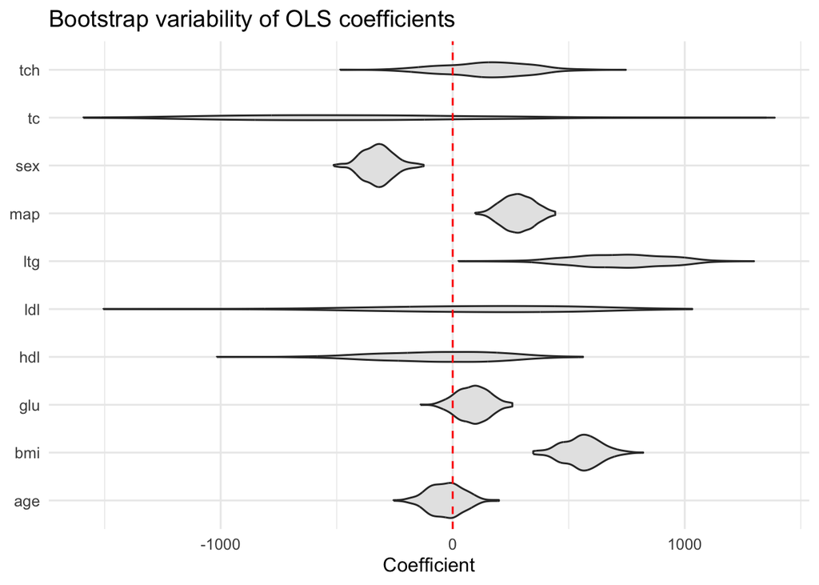

```r
set.seed(123)
B <- 300
boot_coefs <- replicate(B, {
  idx <- sample(nrow(train), replace = TRUE)
  coef(lm(y ~ ., data = train[idx, ]))
})

boot_df <- as_tibble(t(boot_coefs)) %>%
  set_names(names(coef(ols))) %>%
  pivot_longer(everything(), names_to = "term", values_to = "beta")

boot_df %>%
  filter(term != "(Intercept)") %>%
  ggplot(aes(x = term, y = beta)) +
  geom_violin(fill = "grey90") +
  geom_hline(yintercept = 0, linetype = 2, color = "red") +
  coord_flip() +
  labs(title = "Bootstrap variability of OLS coefficients",
       x = NULL, y = "Coefficient") +
  theme_minimal(base_size = 12)
```

## 2.2 OLS generalization error

```r
pred_ols <- predict(ols, newdata = test)
ols_rmse <- rmse(y_te, pred_ols)
tibble(Method = "OLS", Test_RMSE = ols_rmse) %>% kable(digits = 3)
```

| Method | Test_RMSE |
| --- | --- |
| OLS | 58.064 |

# 3 Ridge Regression (L2)

To fit ridge and lasso regresssion models we’ll use the `glmnet` function.

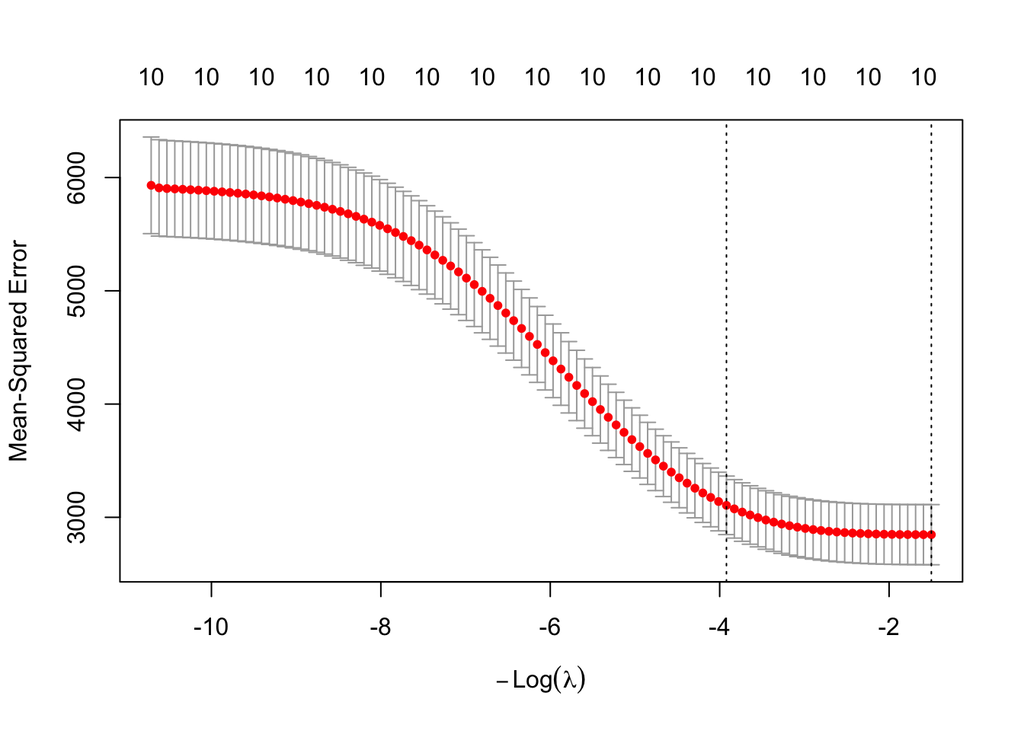

```r
set.seed(1)
cv_ridge <- cv.glmnet(
  X_tr,
  y_tr,
  alpha = 0,
  standardize = TRUE,
  nfolds = 10
)
plot(cv_ridge)
```

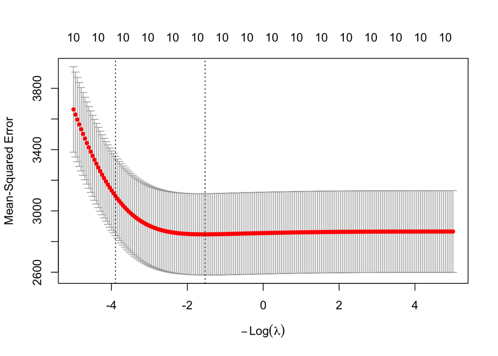

```r
set.seed(1)
cv_ridge <- cv.glmnet(
  X_tr,
  y_tr,
  alpha = 0,
  standardize = TRUE,
  nfolds = 10,
  ## I usually don't specify lambda
  lambda = exp(seq(-5, 5, length.out = 200))
)
plot(cv_ridge)
```

```r
ridge_fit_min <- glmnet(
  X_tr,
  y_tr,
  alpha = 0,
  lambda = cv_ridge$lambda.min,
  standardize = TRUE
  )

ridge_fit_1se <- glmnet(
  X_tr,
  y_tr,
  alpha = 0,
  lambda = cv_ridge$lambda.1se,
  standardize = TRUE
  )

pred_ridge_min <- predict(ridge_fit_min, X_te)
pred_ridge_1se <- predict(ridge_fit_1se, X_te)
rmse_min = rmse(y_te, pred_ridge_min)
rmse_1se = rmse(y_te, pred_ridge_1se)

bind_cols(
  coef_ols = coef(ols),
  coef_ridge_min = coef(ridge_fit_min)[,1],
  coef_ridge_1se = coef(ridge_fit_1se)[,1]
) %>% as.matrix() %>% round(3)
```

```
      coef_ols coef_ridge_min coef_ridge_1se
 [1,]  152.939        152.796        151.752
 [2,]  -31.193        -21.408          7.312
 [3,] -316.425       -292.315       -155.620
 [4,]  555.871        530.920        372.872
 [5,]  283.497        272.335        199.901
 [6,] -510.863       -105.188        -24.282
 [7,]  158.865       -148.147        -84.993
 [8,]  -24.882       -194.640       -176.866
 [9,]  141.600        110.338        124.626
[10,]  743.183        560.341        354.951
[11,]   80.111         86.025        105.381
```

# 4 Lasso (L1)

```r
set.seed(2)
cv_lasso <- cv.glmnet(X_tr, y_tr, alpha = 1, standardize = TRUE, nfolds = 10)
lasso_min  <- glmnet(X_tr, y_tr, alpha = 1, lambda = cv_lasso$lambda.min,  standardize = TRUE)
lasso_1se  <- glmnet(X_tr, y_tr, alpha = 1, lambda = cv_lasso$lambda.1se,  standardize = TRUE)

pred_lasso_min <- predict(lasso_min, X_te)
pred_lasso_1se <- predict(lasso_1se, X_te)

lasso_min_rmse <- rmse(y_te, pred_lasso_min)
lasso_1se_rmse <- rmse(y_te, pred_lasso_1se)

coef(lasso_min)[,1] %>% as.matrix() %>% round(3)
```

```
                [,1]
(Intercept)  152.941
age          -23.505
sex         -307.309
bmi          555.203
map          276.088
tc          -292.826
ldl            0.000
hdl         -127.811
tch           94.592
ltg          670.112
glu           73.603
```

# 5 Partial Least Squares (PLS)

PLS builds latent components that maximize covariance between $X$ and $y$.

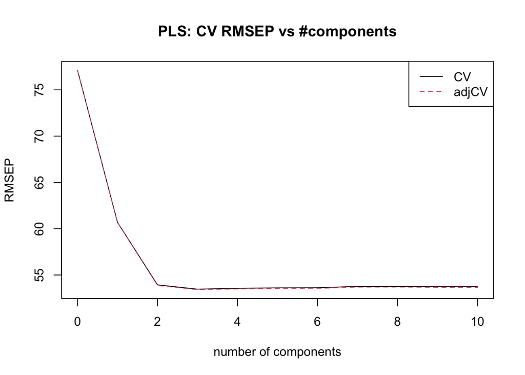

```r
set.seed(3)
pls_fit <- plsr(y ~ ., data = train, validation = "CV")
plot(RMSEP(pls_fit), legendpos = "topright", main = "PLS: CV RMSEP vs #components")
```

```r
# Choose ncomp with lowest CV error (or 1-SE rule)
best_comp <- which.min(RMSEP(pls_fit)$val[estimate = "CV",,, drop = TRUE])
best_comp
```

```
3 comps
      4
```

```r
# Extract the coefficients
pls_coef <- coef(pls_fit, ncomp = best_comp)


pred_pls <- predict(pls_fit, newdata = test, ncomp = best_comp)[,,1]
pls_rmse <- rmse(y_te, pred_pls)
```

# 6 MCP and SCAD (Nonconvex Penalties)

We use `ncvreg` for linear regression with MCP/SCAD penalties; $\lambda$ is tuned via cross-validation.

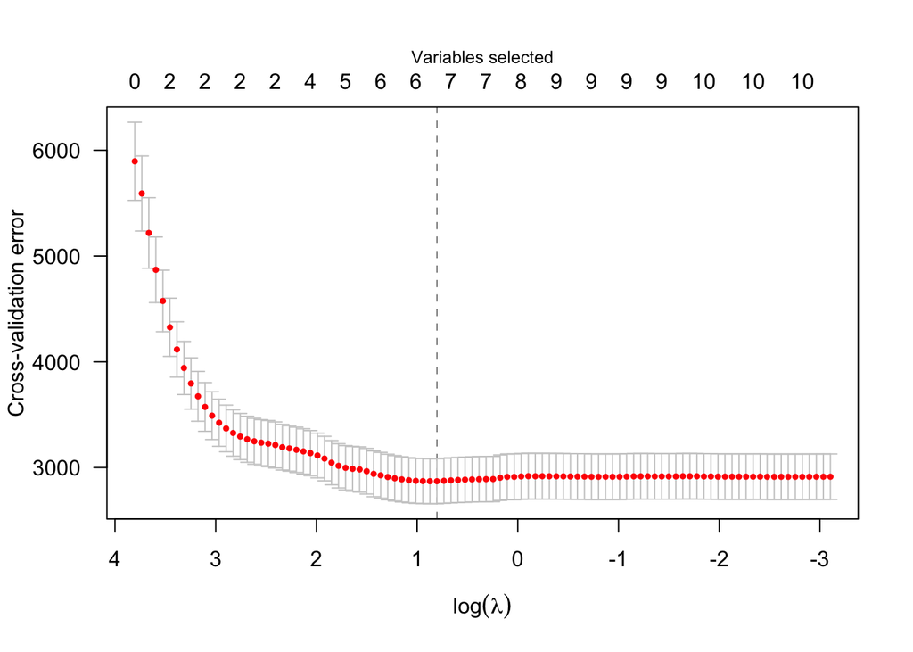

```r
set.seed(4)
cv_mcp  <- cv.ncvreg(X_tr, y_tr, penalty = "MCP",  family = "gaussian", nfolds = 10)
plot(cv_mcp)
```

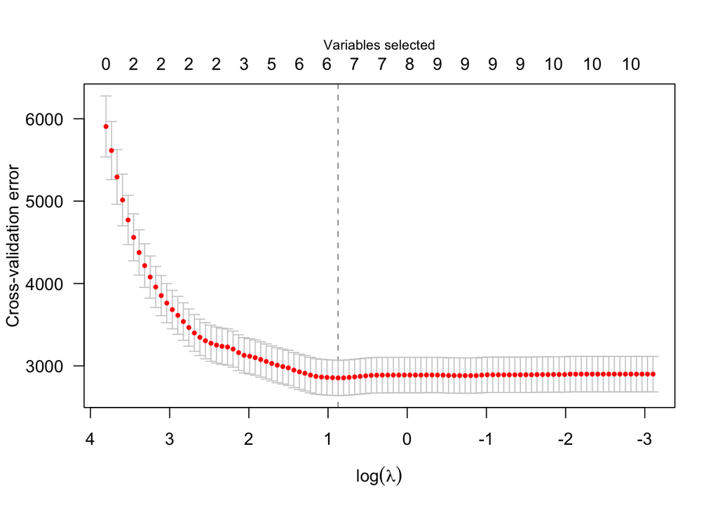

```r
cv_scad <- cv.ncvreg(X_tr, y_tr, penalty = "SCAD", family = "gaussian", nfolds = 10)
plot(cv_scad)
```

```r
mcp_fit  <- cv_mcp$fit
scad_fit <- cv_scad$fit

pred_mcp  <- predict(mcp_fit,  X_te)
pred_scad <- predict(scad_fit, X_te)

mcp_rmse  <- rmse(y_te, pred_mcp)
scad_rmse <- rmse(y_te, pred_scad)


### Beta Coefficients
bind_cols(
  coef_mcp = mcp_fit$beta[,cv_mcp$min],
  coef_scad = scad_fit$beta[,cv_scad$min]
) %>% as.matrix() %>% round(3) %>% kable()
```

| coef_mcp | coef_scad |
| --- | --- |
| 153.063 | 153.064 |
| 0.000 | 0.000 |
| -310.042 | -308.297 |
| 564.197 | 566.241 |
| 280.854 | 282.643 |
| -243.601 | -241.073 |
| 0.000 | 0.000 |
| -205.930 | -206.574 |
| 0.000 | 0.000 |
| 690.954 | 693.973 |
| 19.015 | 5.073 |

# 7 Summary: Test RMSE and Sparsity

```r
summ <- tibble(
  Method = c("OLS","Ridge (min)","Ridge (1SE)","Lasso (min)","Lasso (1SE)","PLS","MCP","SCAD"),
  Test_RMSE = c(
    ols_rmse,
    rmse_min,
    rmse_1se,
    lasso_min_rmse,
    lasso_1se_rmse,
    pls_rmse,
    mcp_rmse,
    scad_rmse
  ),
  Nonzero = c(
    sum(coef(ols)[-1]!=0),
    sum(coef(ridge_fit_min )[-1]!=0),
    sum(coef(ridge_fit_1se )[-1]!=0),
    sum(coef(lasso_min )[-1]!=0),
    sum(coef(lasso_1se )[-1]!=0),
    sum(pls_coef != 0),
    sum(mcp_fit$beta[,cv_mcp$min][-1]!=0),
    sum(scad_fit$beta[,cv_scad$min][-1]!=0)
  )
) %>%
  arrange(Test_RMSE)

summ %>% kable(digits = 3, caption = "Method comparison on held-out test set") %>% kable_styling(full_width = FALSE)
```

Method comparison on held-out test set

| Method | Test_RMSE | Nonzero |
| --- | --- | --- |
| Ridge (1SE) | 56.148 | 10 |
| Lasso (1SE) | 56.426 | 6 |
| Ridge (min) | 57.645 | 10 |
| OLS | 58.064 | 10 |
| Lasso (min) | 58.094 | 9 |
| PLS | 58.489 | 10 |
| MCP | 59.403 | 7 |
| SCAD | 59.738 | 7 |

```r
summ_coef <- tibble(
  Variable = attr(coef(ols)[-1], "names"),
    OLS = coef(ols)[-1],
    Ridge_min = as.vector(coef(ridge_fit_min ))[-1],
    Ridge_1SE = as.vector(coef(ridge_fit_1se ))[-1],
    Lasso_min = as.vector(coef(lasso_min ))[-1],
    Lasso_1SE = as.vector(coef(lasso_1se ))[-1],
    PLS = pls_coef[1:10],
    MCP = mcp_fit$beta[,cv_mcp$min][-1],
    SCAD = scad_fit$beta[,cv_scad$min][-1]
  )

summ_coef %>% kable(digits = 1, caption = "Comparison of Coefficients") %>% kable_styling(full_width = FALSE)
```

Comparison of Coefficients

| Variable | OLS | Ridge_min | Ridge_1SE | Lasso_min | Lasso_1SE | PLS | MCP | SCAD |
| --- | --- | --- | --- | --- | --- | --- | --- | --- |
| age | -31.2 | -21.4 | 7.3 | -23.5 | 0.0 | -27.5 | 0.0 | 0.0 |
| sex | -316.4 | -292.3 | -155.6 | -307.3 | -105.0 | -320.7 | -310.0 | -308.3 |
| bmi | 555.9 | 530.9 | 372.9 | 555.2 | 521.9 | 553.6 | 564.2 | 566.2 |
| map | 283.5 | 272.3 | 199.9 | 276.1 | 144.3 | 289.9 | 280.9 | 282.6 |
| tc | -510.9 | -105.2 | -24.3 | -292.8 | 0.0 | -71.7 | -243.6 | -241.1 |
| ldl | 158.9 | -148.1 | -85.0 | 0.0 | -25.3 | -206.2 | 0.0 | 0.0 |
| hdl | -24.9 | -194.6 | -176.9 | -127.8 | -149.1 | -209.5 | -205.9 | -206.6 |
| tch | 141.6 | 110.3 | 124.6 | 94.6 | 0.0 | 119.6 | 0.0 | 0.0 |
| ltg | 743.2 | 560.3 | 355.0 | 670.1 | 525.5 | 578.8 | 691.0 | 694.0 |
| glu | 80.1 | 86.0 | 105.4 | 73.6 | 0.0 | 73.5 | 19.0 | 5.1 |

# 8 Grouped Lasso (Groups by Clinical Domain)

The diabetes data naturally groups predictors:

- **Demographics:** `age`, `sex`
- **Anthropometrics:** `bmi`, `map`
- **Serum markers:** `tc`–`glu`

We’ll fit a **grouped lasso** to respect these groupings (encouraging selection/deselection by group).

```r
# Build X and groups
X <- df %>%
  select(-"y")
grp_names <- c("age","sex","bmi","map","tc","ldl","hdl","tch","ltg","glu")
stopifnot(all(grp_names %in% names(X)))

gvec <- c(1,1, 2,2, 3,3,3,3,3,3)  # (age,sex)=1; (bmi,bp)=2; (tc..glu)=3
groups <- factor(gvec, labels = c("demo","anthro","serum"))

X_tr_g <- as.matrix(X_tr[, grp_names])
X_te_g <- as.matrix(X_te[, grp_names])

set.seed(5)
cv_grp <- cv.grpreg(X_tr_g, y_tr, group = gvec, penalty = "grLasso", nfolds = 10, family = "gaussian")
grp_fit <- grpreg(X_tr_g, y_tr, group = gvec, penalty = "grLasso", lambda = cv_grp$lambda.min)

pred_grp <- predict(grp_fit, X_te_g)
grp_rmse <- rmse(y_te, pred_grp)
grp_rmse
```

```
[1] 57.55085
```

Inspect which **groups** entered:

```r
beta_grp <- coef(grp_fit)[-1]  # drop intercept
tibble(var = grp_names, beta = as.numeric(beta_grp),
       group = groups) %>%
  group_by(group) %>%
  summarise(any_selected = any(beta != 0), n_nonzero = sum(beta != 0)) %>%
  kable(caption = "Grouped-lasso selection by group")
```

Grouped-lasso selection by group

| group | any_selected | n_nonzero |
| --- | --- | --- |
| demo | TRUE | 2 |
| anthro | TRUE | 2 |
| serum | TRUE | 6 |

# 9 Fused Lasso (Environmental Time Series Denoising)

Fused lasso encourages **piecewise-constant** signals by penalizing the sum of absolute differences between adjacent coefficients (a total-variation penalty). Unlike generalized trend filtering, this is the original fused lasso estimator (Tibshirani et al., 2005), fit directly with `genlasso::fusedlasso1d()`. We denoise **daily Ozone** (public health air quality) from the `airquality` dataset.

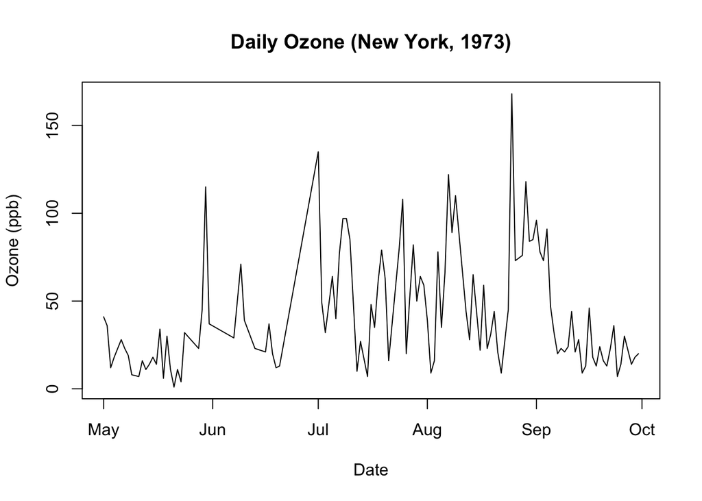

```r
oz <- airquality %>%
  mutate(date = as.Date(sprintf("1973-%02d-%02d", Month, Day))) %>%
  arrange(date) %>%
  select(date, Ozone) %>%
  drop_na()

plot(oz$date, oz$Ozone, type = "l", xlab = "Date", ylab = "Ozone (ppb)",
     main = "Daily Ozone (New York, 1973)")
```

Fit the fused lasso path and inspect it to choose a reasonable amount of smoothing:

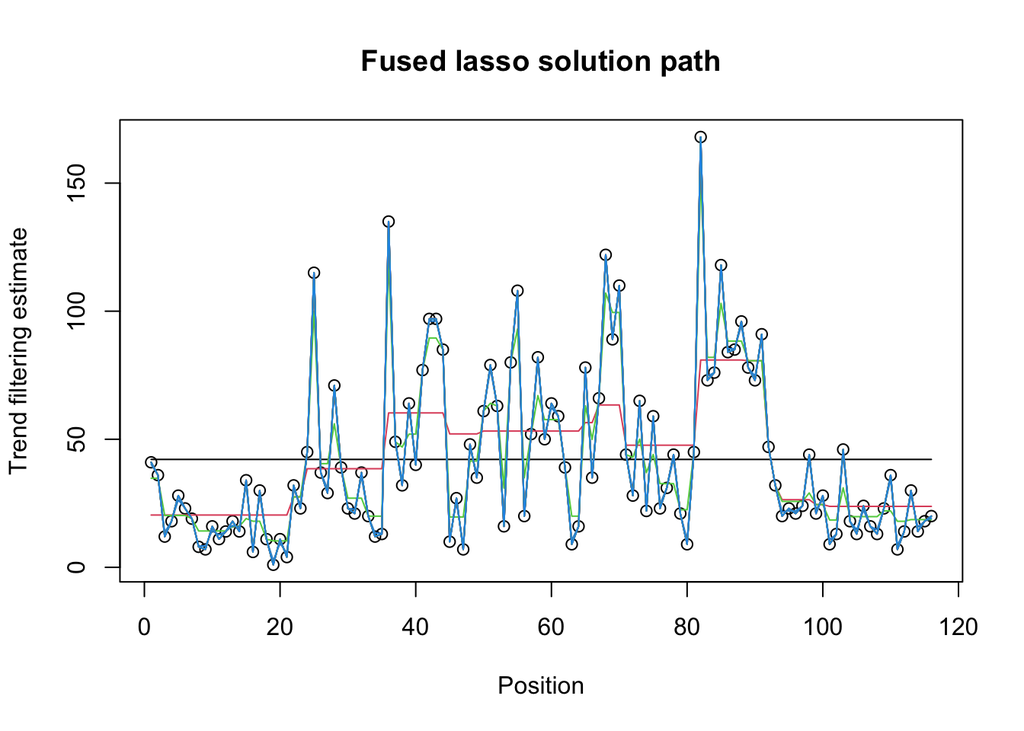

```r
y <- oz$Ozone

# Bona fide fused lasso: penalizes sum(|beta_i - beta_{i-1}|)
fl <- fusedlasso1d(y)

plot(fl, main = "Fused lasso solution path")
```

```r
# Pick a moderately smooth fit along the path (adjust after visual inspection)
lambda_choice <- fl$lambda[50]
beta_hat <- coef(fl, lambda = lambda_choice)$beta
```

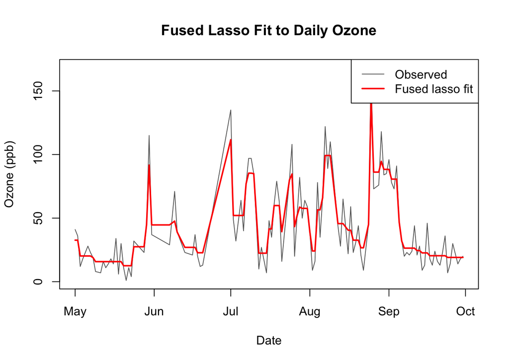

```r
plot(oz$date, y, type = "l", col = "gray40",
     xlab = "Date", ylab = "Ozone (ppb)",
     main = "Fused Lasso Fit to Daily Ozone")
lines(oz$date, beta_hat, col = "red", lwd = 2)
legend("topright", legend = c("Observed", "Fused lasso fit"),
       col = c("gray40", "red"), lty = 1, lwd = c(1, 2))
```

> **Interpretation:** the fused lasso identifies **regime shifts/plateaus** in ozone levels — stretches of days the model treats as a stable pollution level, separated by abrupt jumps. This is useful for environmental health monitoring and change-point detection, and unlike a moving average or spline smoother, it does not blur across a genuine jump in the underlying signal. —

# 10 Takeaways

- **OLS** can be unstable with correlated predictors; bootstrap variability shows why shrinkage helps.
- **Ridge** shrinks coefficients (lower variance), **Lasso/MCP/SCAD** add sparsity for interpretability.
- **PLS** is strong when predictors are highly collinear and signal is low-dimensional in the latent space.
- **Grouped lasso** encodes domain structure (e.g., demographics vs labs), selecting groups coherently.
- **Fused lasso** is powerful for ordered structures (time, space, genomic position), producing interpretable plateaus.